# Tutorial 3: Figure 2

Wei-Chun Chou

June, 2020

# Introduction

This tutorial aims to guide you to step-by-step reproduce the results of Figure 2. We estimate the R-square value and goodness-of-fit using linear regression model.

# Prerequisites

Before running your model, you should set up your working directory, compile the PBPK model, install all required packages and input needed datasets. The model file and datasets can be found in the additional files.

## Setting up your working directory

Before running, you should change your working directory to the **PlotCode** folder. You can use two ways to change your working directory as follow:

1. Use RStudio: use the menu to change your working directory under **Session > Set Working Directory > Choose Directory**.
2. Use R function: use the R function `setwd()` to change the path to your working directory.

## Loading required R package

The list of R packages should be installed first prior to the simulation. If you have not installed these packages (listed below), please install these packages to your Rstudio using the R function `require (" ")` and then use `library` to open it.

```r
##  Loading requried R package
library(mrgsolve)    ## R-package for Loading mrgsolve code into r via mcode from the 'mrgsolve' pckage
library(magrittr)    ## R-package for the pipe, %>% , comes from the magrittr package by Stefan Milton Bache
library(dplyr)       ## R-package for transform and summarize tabular data with rows and columns; %>%
library(tidyverse)   ## R-package for transform and summarize tabular data with rows and columns; %>%
library(ggplot2)     ## R-package for GGplot
library(FME)         ## R-package for model fitting
library(minpack.lm)  ## R-package for model fitting
library(gridExtra)   ## R-package for function "grid.arrange"
```

## Read mrgsolve-based PBPK Model R file

The rat pre-pregnant, gestational and lactational PBPK model were written in `RMod.R` file. Before compiling the model, please call this file using R function `source`. Same for the human model.

```r
## Input mrgsolve-based PBPK Model
source (file = "RMod.R")  ## input the rat model for nonpregnnat, geatation and lactation
source (file = "HMod.R")  ## input the human model for nonpregnnat, geatation and lactation
```

## Complie mrgsolve-based PBPK Model

Read the code and build these mrgsolve-based PBPK model. You should make sure all models are built correctly.

```r
## Build mrgsolve-based PBPK Model
PreGmod_R <- mcode ("PreG_RatPBPK.code", PreG_RatPBPK.code)
```

```
## Building PreG_RatPBPK_code ... done.
```

```r
Gmod_R    <- mcode ("GRatPBPK.code", GRatPBPK.code)
```

```
## Building GRatPBPK_code ... done.
```

```r
Lmod_R    <- mcode ("LRatPBPK.code", LRatPBPK.code)
```

```
## Building LRatPBPK_code ... done.
```

```r
PreGmod_H <- mcode ("PreGHumanPBPK.code", PreGHumanPBPK.code)
```

```
## Building PreGHumanPBPK_code ... done.
```

```r
Gmod_H    <- mcode ("GHumanPBPK.code", GHumanPBPK.code)
```

```
## Building GHumanPBPK_code ... done.
```

```r
Lmod_H    <- mcode ("LHumanPBPK.code", LHumanPBPK.code)
```

```
## Building LHumanPBPK_code ... done.
```

## Loading datasets

In this step, you need to input the .csv file to the Rstudio. The function `read.csv` can be used to read the csv files into R

```r
RDat <- read.csv(file = "Data_R.csv")
HDat <- read.csv(file = "Data_H.csv")
```

## Loading Fit results from rds files to obtain parameter values

```r
GFit_R <- readRDS(file = "GFit_R.rds")
LFit_R <- readRDS(file = "LFit_R.rds")
GFit_H <- readRDS(file = "GFit_H.rds")
LFit_H <- readRDS(file = "LFit_H.rds")
```

## Input mrgsolve-based PBPK Model as a prediction function

```r
source (file = "Pred_Rat.R")
source (file = "Pred_H.R")
```

# Input the rat and human datasets

## Read the rat datasets

There are two rat datasets (A and B) collected from Thibodeaux et al., 2003 and Chang et al., 2009:

Model calibration data A for rats.  
- Reference: Thibodeaux et al., 2003;  
- Dose regimen: 1, 2, 3, 5, 10 mg/kg/day, exposure from GD2 - GD20.  
- Abreviation: maternal plasma (MP), maternal liver (ML), fetal liver (FL)

```r
## Model calibration data A for rats ====================================================
# A1. : Pregnant SD rat oral dose to 1 mg/kg,  matrix: MP, Sampling time: GD7, 14 and 21
# A2. : Pregnant SD rat oral dose to 2 mg/kg,  matrix: MP, Sampling time: GD7, 14 and 21
# A3. : Pregnant SD rat oral dose to 3 mg/kg,  matrix: MP, Sampling time: GD7, 14 and 21
# A4. : Pregnant SD rat oral dose to 5 mg/kg,  matrix: MP, Sampling time: GD7, 14 and 21
# A5. : Pregnant SD rat oral dose to 10 mg/kg, matrix: MP, Sampling time: GD7, 14 and 21
# A6. : Pregnant SD rat oral dose to 1 mg/kg,  matrix: ML, Sampling time: GD21
# A7. : Pregnant SD rat oral dose to 2 mg/kg,  matrix: ML, Sampling time: GD21
# A8. : Pregnant SD rat oral dose to 3 mg/kg,  matrix: ML, Sampling time: GD21
# A9. : Pregnant SD rat oral dose to 5 mg/kg,  matrix: ML, Sampling time: GD21
# A10 : Pregnant SD rat oral dose to 10 mg/kg, matrix: ML, Sampling time: GD21
# A11.: Pregnant SD rat oral dose to 1 mg/kg,  matrix: FL, Sampling time: GD21
# A12.: Pregnant SD rat oral dose to 2 mg/kg,  matrix: FL, Sampling time: GD21
# A13.: Pregnant SD rat oral dose to 3 mg/kg,  matrix: FL, Sampling time: GD21
# A14.: Pregnant SD rat oral dose to 5 mg/kg,  matrix: FL, Sampling time: GD21
# A15 : Pregnant SD rat oral dose to 10 mg/kg, matrix: FL, Sampling time: GD21
#=======================================================================================

OBS_R_A1  <- RDat %>% filter(Study == 1 & Sample == "MP" & Dose == 1   & Time != 0) %>% select(Time = "Time", CPlas = "Conc")
OBS_R_A2  <- RDat %>% filter(Study == 1 & Sample == "MP" & Dose == 2   & Time != 0) %>% select(Time = "Time", CPlas = "Conc")
OBS_R_A3  <- RDat %>% filter(Study == 1 & Sample == "MP" & Dose == 3   & Time != 0) %>% select(Time = "Time", CPlas = "Conc")
OBS_R_A4  <- RDat %>% filter(Study == 1 & Sample == "MP" & Dose == 5   & Time != 0) %>% select(Time = "Time", CPlas = "Conc")
OBS_R_A5  <- RDat %>% filter(Study == 1 & Sample == "MP" & Dose == 10  & Time != 0) %>% select(Time = "Time", CPlas = "Conc")
OBS_R_A6  <- RDat %>% filter(Study == 1 & Sample == "ML" & Dose == 1   & Time != 0) %>% select(Time = "Time", CL    = "Conc")
OBS_R_A7  <- RDat %>% filter(Study == 1 & Sample == "ML" & Dose == 2   & Time != 0) %>% select(Time = "Time", CL    = "Conc")
OBS_R_A8  <- RDat %>% filter(Study == 1 & Sample == "ML" & Dose == 3   & Time != 0) %>% select(Time = "Time", CL    = "Conc")
OBS_R_A9  <- RDat %>% filter(Study == 1 & Sample == "ML" & Dose == 5   & Time != 0) %>% select(Time = "Time", CL    = "Conc")
OBS_R_A10 <- RDat %>% filter(Study == 1 & Sample == "ML" & Dose == 10  & Time != 0) %>% select(Time = "Time", CL    = "Conc")
OBS_R_A11 <- RDat %>% filter(Study == 1 & Sample == "FL" & Dose == 1   & Time != 0) %>% select(Time = "Time", CFL   = "Conc")
OBS_R_A12 <- RDat %>% filter(Study == 1 & Sample == "FL" & Dose == 2   & Time != 0) %>% select(Time = "Time", CFL   = "Conc")
OBS_R_A13 <- RDat %>% filter(Study == 1 & Sample == "FL" & Dose == 3   & Time != 0) %>% select(Time = "Time", CFL   = "Conc")
OBS_R_A14 <- RDat %>% filter(Study == 1 & Sample == "FL" & Dose == 5   & Time != 0) %>% select(Time = "Time", CFL   = "Conc")
OBS_R_A15 <- RDat %>% filter(Study == 1 & Sample == "FL" & Dose == 10  & Time != 0) %>% select(Time = "Time", CFL   = "Conc")
```

Model calibration data B for rats.  
- Reference: Chang et al., 2009;  
- Dose regimen: 0.1, 0.3, 1 mg/kg/day; exposure from GD0 (day positive for mating) through PND20.  
- Abreviation: D: Dam, P: Pup, MP: maternal plasma, ML: maternal liver, NP: neonatal plasma, NL: neonatal liver.

```r
## Model calibration data B for rats =========================================================
# B1. : Pregnant SD rat oral dose to 0.1 mg/kg,  matrix: MP, Sampling time: GD20, PND4, PND21
# B2. : Pregnant SD rat oral dose to 0.3 mg/kg,  matrix: MP, Sampling time: GD20, PND4, PND21
# B3. : Pregnant SD rat oral dose to 1 mg/kg,    matrix: MP, Sampling time: GD20, PND4, PND21
# B4. : Pregnant SD rat oral dose to 0.1 mg/kg,  matrix: NP, Sampling time: GD20, PND4, PND21
# B5. : Pregnant SD rat oral dose to 0.3 mg/kg,  matrix: NP, Sampling time: GD20, PND4, PND21
# B6. : Pregnant SD rat oral dose to 1 mg/kg,    matrix: NP, Sampling time: GD20, PND4, PND21
# B7. : Pregnant SD rat oral dose to 0.1 mg/kg,  matrix: NL, Sampling time: GD20, PND4, PND21
# B8. : Pregnant SD rat oral dose to 0.3 mg/kg,  matrix: NL, Sampling time: GD20, PND4, PND21
# B9. : Pregnant SD rat oral dose to 1 mg/kg,    matrix: NL, Sampling time: GD20, PND4, PND21
#============================================================================================

OBS_R_B1  <- RDat %>% filter(Study == 2 & Sample == "MP" & Dose == 1   & Time > 480)%>% select(Time = "Time", CPlas = "Conc")
OBS_R_B2  <- RDat %>% filter(Study == 2 & Sample == "MP" & Dose == 0.3 & Time > 480)%>% select(Time = "Time", CPlas = "Conc")
OBS_R_B3  <- RDat %>% filter(Study == 2 & Sample == "MP" & Dose == 0.1 & Time > 480)%>% select(Time = "Time", CPlas = "Conc")
OBS_R_B4  <- RDat %>% filter(Study == 2 & Sample == "NP" & Dose == 1   & Time > 480)%>% select(Time = "Time", CPlas_pup = "Conc")
OBS_R_B5  <- RDat %>% filter(Study == 2 & Sample == "NP" & Dose == 0.3 & Time > 480)%>% select(Time = "Time", CPlas_pup = "Conc")
OBS_R_B6  <- RDat %>% filter(Study == 2 & Sample == "NP" & Dose == 0.1 & Time > 480)%>% select(Time = "Time", CPlas_pup = "Conc")
OBS_R_B7  <- RDat %>% filter(Study == 2 & Sample == "NL" & Dose == 1   & Time > 480)%>% select(Time = "Time", CL_pup = "Conc")
OBS_R_B8  <- RDat %>% filter(Study == 2 & Sample == "NL" & Dose == 0.3 & Time > 480)%>% select(Time = "Time", CL_pup = "Conc")
OBS_R_B9  <- RDat %>% filter(Study == 2 & Sample == "NL" & Dose == 0.1 & Time > 480)%>% select(Time = "Time", CL_pup = "Conc")
```

## Read the human datasets

There are two datasets (A and B) collected from several human biomonitoring studies:  
Model calibration data A for human.  
- Abreviation: MP: Maternal plasma, CB: cord blood, Pla: placenta; Fli: Fetal liver

```r
## Model calibration data for human ===============================================
# A1. (Inoue et al., 2004)         : Japanese population;   Matrix: MP, CB
# A2. (Fei et al., 2007)           : Danish population;  Matrix: MP, CB
# A3. (Kato et al., 2014)          : U.S. population;    Matrix: MP, CB
# A4. (Pan et al., 2017)           : Chinese population; Matrix: MP, CB
# A5. (Mamsen et al., 2019)        : Sweden population;  Matrix: MP, Pla
# B1. (Karrman et al. (2007)       : Sweden population;  Matrix: MP, Milk
# B2. (Von Ehrenstein et al., 2009): U.S. population;    Matrix: MP
# B3. (Fromme et al., 2010)        : Germany population; Matrix: MP, NP
#====================================================================================

## Read the data and later used in model calibration and evaluation
OBS_H_A1_MP     <- HDat %>% filter(Study == 1  & Matrix == "MP")   %>% select(Time = "Time",  CPlas     = "Conc")
OBS_H_A1_CB     <- HDat %>% filter(Study == 1  & Matrix == "CB")   %>% select(Time = "Time",  CFPlas    = "Conc")
OBS_H_A2_MP     <- HDat %>% filter(Study == 2  & Matrix == "MP")   %>% select(Time = "Time",  CPlas     = "Conc")
OBS_H_A2_CB     <- HDat %>% filter(Study == 2  & Matrix == "CB")   %>% select(Time = "Time",  CFPlas    = "Conc")
OBS_H_A3_MP     <- HDat %>% filter(Study == 3  & Matrix == "MP")   %>% select(Time = "Time",  CPlas     = "Conc")
OBS_H_A3_CB     <- HDat %>% filter(Study == 3  & Matrix == "CB")   %>% select(Time = "Time",  CFPlas    = "Conc")
OBS_H_A4_MP     <- HDat %>% filter(Study == 4  & Matrix == "MP")   %>% select(Time = "Time",  CPlas     = "Conc")
OBS_H_A4_CB     <- HDat %>% filter(Study == 4  & Matrix == "CB")   %>% select(Time = "Time",  CFPlas    = "Conc")
OBS_H_A5_MP     <- HDat %>% filter(Study == 5  & Matrix == "MP")   %>% select(Time = "Time",  CPlas     = "Conc")
OBS_H_A5_Pla    <- HDat %>% filter(Study == 5  & Matrix == "Pla")  %>% select(Time = "Time",  CPla      = "Conc")
OBS_H_A5_Fli    <- HDat %>% filter(Study == 5  & Matrix == "Fli")  %>% select(Time = "Time",  CFL       = "Conc")
OBS_H_A6_MP     <- HDat %>% filter(Study == 6  & Matrix == "MP")   %>% select(Time = "Time",  CPlas     = "Conc")
OBS_H_A6_CB     <- HDat %>% filter(Study == 6  & Matrix == "CB")   %>% select(Time = "Time",  CFPlas    = "Conc")
OBS_H_B1_MP     <- HDat %>% filter(Study == 16 & Matrix == "MP")   %>% select(Time = "Time",  CPlas     = "Conc")
OBS_H_B1_Milk   <- HDat %>% filter(Study == 16 & Matrix == "Milk") %>% select(Time = "Time",  CMilk     = "Conc")
OBS_H_B2_MP     <- HDat %>% filter(Study == 17 & Matrix == "MP")   %>% select(Time = "Time",  CPlas     = "Conc")
OBS_H_B3_MP     <- HDat %>% filter(Study == 18 & Matrix == "MP")   %>% select(Time = "Time",  CPlas     = "Conc")
OBS_H_B3_NP     <- HDat %>% filter(Study == 18 & Matrix == "NP")   %>% select(Time = "Time",  CPlas_pup = "Conc")
OBS_H_B4_Milk   <- HDat %>% filter(Study == 19 & Matrix == "Milk") %>% select(Time = "Time",  CMilk     = "Conc")
```

# Define the cost function to calculate the model residual

```r
## Cost function for rats
R_Cost<-function (Gpars_R, Lpars_R){ # DOSE is based on the exposure scenario from the literature (Thibodeaux et al., 2003 and Change et al., 2009)
    outdf.A1 <- pred.A (Gpars = Gpars_R,  DOSE = 1)
    outdf.A2 <- pred.A (Gpars = Gpars_R,  DOSE = 2)
    outdf.A3 <- pred.A (Gpars = Gpars_R,  DOSE = 3)
    outdf.A4 <- pred.A (Gpars = Gpars_R,  DOSE = 5)
    outdf.A5 <- pred.A (Gpars = Gpars_R,  DOSE = 10)
    outdf.A  <- pred.B (Lpars = Lpars_R,  DOSE = 1)
    outdf.B  <- pred.B (Lpars = Lpars_R,  DOSE = 0.3)
    outdf.C  <- pred.B (Lpars = Lpars_R,  DOSE = 0.1)

    cost<- modCost  (model = outdf.A1, obs = OBS_R_A1, x ="Time")
    cost<- modCost  (model = outdf.A2, obs = OBS_R_A2, x ="Time", cost = cost)
    cost<- modCost  (model = outdf.A3, obs = OBS_R_A3, x ="Time", cost = cost)
    cost<- modCost  (model = outdf.A4, obs = OBS_R_A4, x ="Time", cost = cost)
    cost<- modCost  (model = outdf.A5, obs = OBS_R_A5, x ="Time", cost = cost)
    cost<- modCost  (model = outdf.A1, obs = OBS_R_A6, x ="Time", cost = cost)
    cost<- modCost  (model = outdf.A2, obs = OBS_R_A7, x ="Time", cost = cost)
    cost<- modCost  (model = outdf.A3, obs = OBS_R_A8, x ="Time", cost = cost)
    cost<- modCost  (model = outdf.A4, obs = OBS_R_A9, x ="Time", cost = cost)
    cost<- modCost  (model = outdf.A5, obs = OBS_R_A10,x ="Time", cost = cost)
    cost<- modCost  (model = outdf.A1, obs = OBS_R_A11,x ="Time", cost = cost)
    cost<- modCost  (model = outdf.A2, obs = OBS_R_A12,x ="Time", cost = cost)
    cost<- modCost  (model = outdf.A3, obs = OBS_R_A13,x ="Time", cost = cost)
    cost<- modCost  (model = outdf.A4, obs = OBS_R_A14,x ="Time", cost = cost)
    cost<- modCost  (model = outdf.A5, obs = OBS_R_A15,x ="Time", cost = cost)
    cost<- modCost  (model = outdf.A,  obs = OBS_R_B1, x ="Time", cost = cost)
    cost<- modCost  (model = outdf.B,  obs = OBS_R_B2, x ="Time", cost = cost)
    cost<- modCost  (model = outdf.C,  obs = OBS_R_B3, x ="Time", cost = cost)
    cost<- modCost  (model = outdf.A,  obs = OBS_R_B4, x ="Time", cost = cost)
    cost<- modCost  (model = outdf.B,  obs = OBS_R_B5, x ="Time", cost = cost)
    cost<- modCost  (model = outdf.C,  obs = OBS_R_B6, x ="Time", cost = cost)
    cost<- modCost  (model = outdf.A,  obs = OBS_R_B7, x ="Time", cost = cost)
    cost<- modCost  (model = outdf.B,  obs = OBS_R_B8, x ="Time", cost = cost)
    cost<- modCost  (model = outdf.C,  obs = OBS_R_B9, x ="Time", cost = cost)
    return(cost)
}

## Cost function for humans
H_Cost<-function (Gpars_H, Lpars_H){ ## DOSE_A1 - B4 were defined in the prediction function "Pred_H.R"
    outdf.A1 <- pred.G (Gpars = Gpars_H,  DOSE = DOSE_A1, Init = Init_A1)
    outdf.A2 <- pred.G (Gpars = Gpars_H,  DOSE = DOSE_A2, Init = Init_A2)
    outdf.A3 <- pred.G (Gpars = Gpars_H,  DOSE = DOSE_A3, Init = Init_A3)
    outdf.A4 <- pred.G (Gpars = Gpars_H,  DOSE = DOSE_A4, Init = Init_A4)
    outdf.A5 <- pred.G (Gpars = Gpars_H,  DOSE = DOSE_A5, Init = Init_A5)
    outdf.A6 <- pred.G (Gpars = Gpars_H,  DOSE = DOSE_A6, Init = Init_A6)
    outdf.B1 <- pred.L (Lpars = Lpars_H,  DOSE = DOSE_B1, Init_G = Init_G1)
    outdf.B2 <- pred.L (Lpars = Lpars_H,  DOSE = DOSE_B2, Init_G = Init_G2)
    outdf.B3 <- pred.L (Lpars = Lpars_H,  DOSE = DOSE_B3, Init_G = Init_G3)
    outdf.B4 <- pred.L (Lpars = Lpars_H,  DOSE = DOSE_B4, Init_G = Init_G4)

    cost<- modCost  (model = outdf.A1, obs = OBS_H_A1_MP,  x ="Time")
    cost<- modCost  (model = outdf.A1, obs = OBS_H_A1_CB,  x ="Time", cost = cost)
    cost<- modCost  (model = outdf.A2, obs = OBS_H_A2_MP,  x ="Time", cost = cost)
    cost<- modCost  (model = outdf.A2, obs = OBS_H_A2_CB,  x ="Time", cost = cost)
    cost<- modCost  (model = outdf.A3, obs = OBS_H_A3_MP,  x ="Time", cost = cost)
    cost<- modCost  (model = outdf.A3, obs = OBS_H_A3_CB,  x ="Time", cost = cost)
    cost<- modCost  (model = outdf.A4, obs = OBS_H_A4_MP,  x ="Time", cost = cost)
    cost<- modCost  (model = outdf.A4, obs = OBS_H_A4_CB,  x ="Time", cost = cost)
    cost<- modCost  (model = outdf.A4, obs = OBS_H_A5_MP,  x ="Time", cost = cost)
    cost<- modCost  (model = outdf.A4, obs = OBS_H_A5_Pla, x ="Time", cost = cost)
    cost<- modCost  (model = outdf.A4, obs = OBS_H_A5_Fli, x ="Time", cost = cost)
    cost<- modCost  (model = outdf.A6, obs = OBS_H_A6_MP,  x ="Time", cost = cost)
    cost<- modCost  (model = outdf.A6, obs = OBS_H_A6_CB,  x ="Time", cost = cost)
    cost<- modCost  (model = outdf.B1, obs = OBS_H_B1_MP,  x ="Time", cost = cost)
    cost<- modCost  (model = outdf.B1, obs = OBS_H_B1_Milk,x ="Time", cost = cost)
    cost<- modCost  (model = outdf.B2, obs = OBS_H_B2_MP,  x ="Time", cost = cost)
    cost<- modCost  (model = outdf.B3, obs = OBS_H_B3_MP,  x ="Time", cost = cost)
    cost<- modCost  (model = outdf.B3, obs = OBS_H_B3_NP,  x ="Time", cost = cost)
    cost<- modCost  (model = outdf.B4, obs = OBS_H_B4_Milk,x ="Time", cost = cost)


    return(cost)
}
```

## Input the optimized parameter values into the cost function

```r
RatCost   <- R_Cost(GFit_R$par, LFit_R$par)
```

[output not shown]

[output cut: 16 more lines]

[output not shown]

```r
HumanCost <- H_Cost(GFit_H$par, LFit_H$par)
```

[output not shown]

# Make the plotdata for later used in ploting

```r
## Combine the predicted values and observed data in rats to the object 'GPDat'
GPDat <- cbind.data.frame (OBS = RatCost$residuals$obs,
                           PRE = RatCost$residuals$mod)

## Combine the predicted values and observed data in humans to the object 'HPDat'
HPDat <- cbind.data.frame (OBS = HumanCost$residuals$obs,
                           PRE = HumanCost$residuals$mod)

## Transformed the predicted and obseved values using log10-sacle to do the plot
GPDat %<>% mutate (Log.OBS = log(OBS,10), Log.PRE = log(PRE,10), Species = "Rat")
HPDat %<>% mutate (Log.OBS = log(OBS,10), Log.PRE = log(PRE,10), Species = "Human")
PlotDat <- rbind(GPDat, HPDat)
```

# Estimating the R-squared and goodness-of-fit using linear regression model

We can perform linear regression on the data using the `lm()` function:

```r
fit <- lm(Log.OBS ~ Log.PRE, data = PlotDat)
summary(fit)
```

```
##
## Call:
## lm(formula = Log.OBS ~ Log.PRE, data = PlotDat)
##
## Residuals:
##      Min       1Q   Median       3Q      Max
## -0.39334 -0.04843  0.00850  0.06704  0.26940
##
## Coefficients:
##             Estimate Std. Error t value Pr(>|t|)
## (Intercept)  0.06078    0.02108   2.883  0.00515 **
## Log.PRE      0.96576    0.01494  64.623  < 2e-16 ***
## ---
## Signif. codes:  0 '***' 0.001 '**' 0.01 '*' 0.05 '.' 0.1 ' ' 1
##
## Residual standard error: 0.1203 on 74 degrees of freedom
## Multiple R-squared:  0.9826, Adjusted R-squared:  0.9824
## F-statistic:  4176 on 1 and 74 DF,  p-value: < 2.2e-16
```

We see that, according to the model, the adjusted r-squared is 0.98 and the p-value is <2.2e-16. It means that the predicted values are in agreement with the observed data.

# Manipulate the figures

## Figure 2a

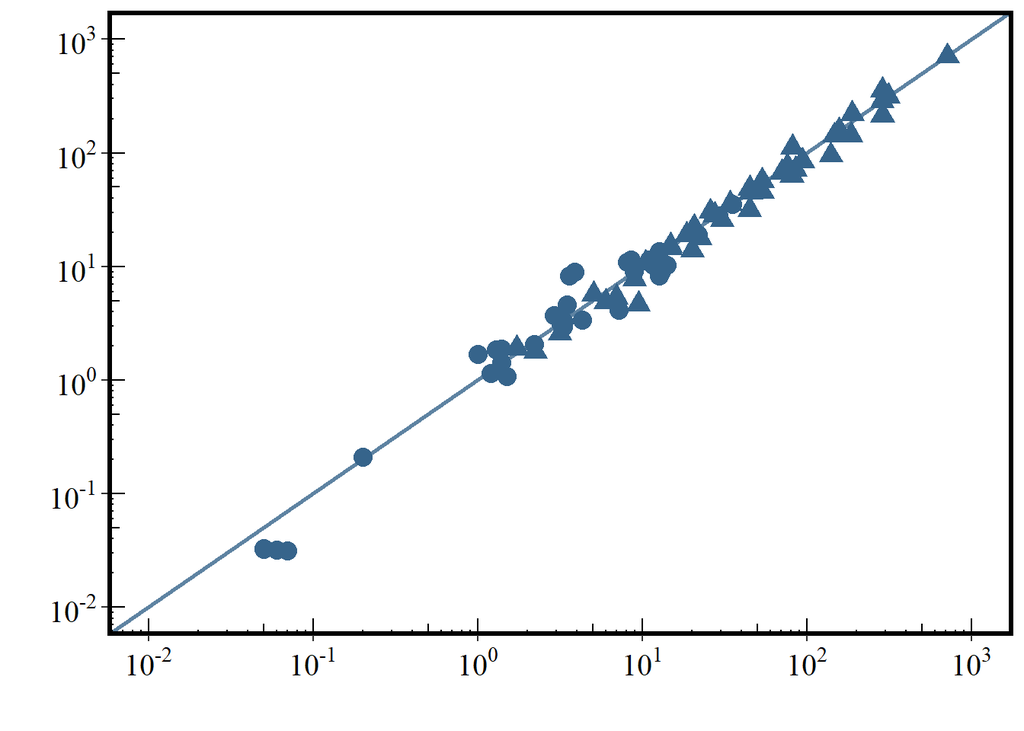

```r
PlotDat %<>% mutate(res = residuals(fit),
                    prediction = predict(fit),
                    OPR = PRE/OBS) ## OPR: the ratio of prediction value and observed data

p <-
    ggplot(PlotDat, aes(Log.OBS, Log.PRE)) + ## using log-sacle axis
    geom_point  (aes(shape   = as.factor(Species)), colour = "steelblue4", size = 4)  +
    geom_abline (intercept = 0,
                 slope     = 1,
                 color     ="steelblue4", size = 1, alpha = 0.8) +
    annotation_logticks() +
    scale_y_continuous(limits = c(-2,3), labels = scales::math_format(10^.x))+
    scale_x_continuous(limits = c(-2,3),labels = scales::math_format(10^.x))

## Set up your theme and font
windowsFonts("Times" = windowsFont("Times New Roman"))

p1 <- p +
    theme (
        plot.background         = element_rect (fill="White"),
        text                    = element_text (family = "Times"),   # text front (Time new roman)
        panel.border            = element_rect (colour = "black", fill=NA, size=2),
        panel.background        = element_rect (fill="White"),
        panel.grid.major        = element_blank(),
        panel.grid.minor        = element_blank(),
        axis.text               = element_text (size   = 15, colour = "black", face = "bold"),    # tick labels along axes
        axis.title              = element_text (size   = 18, colour = "black", face = "bold"),   # label of axes
        legend.position         ='none') +
    labs (x = "",  y = "")

p1
```

## Figure 2b

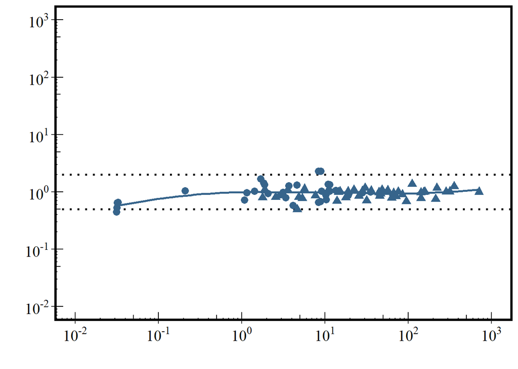

```r
p2 <-
    ggplot(PlotDat, aes(Log.PRE, log(OPR,10))) +
    geom_hline(yintercept = log10(2),linetype = 3, color   = "black", size =1) +
    geom_hline(yintercept = log10(0.5),linetype = 3, color   = "black", size =1) +
    geom_point(color   = "steelblue4",
               aes(shape= as.factor(Species)),size = 3) +
    geom_smooth(color="steelblue4",method="loess", se = FALSE, size = 1) +
    annotation_logticks() +
    scale_y_continuous(limits = c(-2,3), labels = scales::math_format(10^.x))+
    scale_x_continuous(limits = c(-2,3),labels = scales::math_format(10^.x))

p2 <- p2 +
    theme (
        plot.background         = element_rect (fill ="White"),
        text                    = element_text (family = "Times"),   # text front (Time new roman)
        panel.border            = element_rect (colour = "black", fill=NA, size=2),
        panel.background        = element_rect (fill ="White"),
        panel.grid.major        = element_blank(),
        panel.grid.minor        = element_blank(),
        axis.text               = element_text (size   = 15, colour = "black", face = "bold"),    # tick labels along axes
        axis.title              = element_text (size   = 18, colour = "black", face = "bold"),   # label of axes
        legend.position='none') +
    labs (x = "", y = "")

p2
```

## Combine two plots

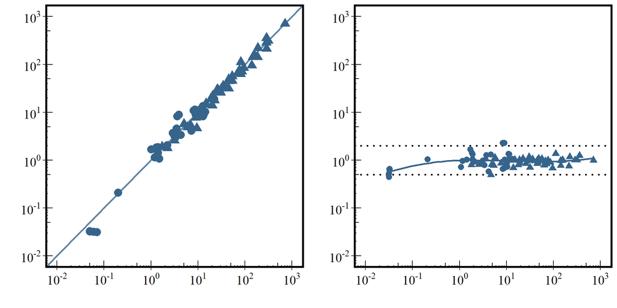

```r
grid.arrange(p1, p2, nrow = 1)
```

## Save your figure

Save your figures using `ggsave()`. In the `ggsave` function, you should set up the your path to save your figure in the local drive.

```r
# ggsave("Fig.2.tiff",scale = 1,
#        plot = grid.arrange(p1, p2, nrow = 1),
#        path = "C:/Users/Desktop",
#        width = 25, height = 12, units = "cm", dpi=320)
#
#
# dev.off()
```